# Practice 3 - GS

Marcio Resende, Professor[^1]

Paul Adunola, PhD student[^2]

2023-11-16

## Introduction

This script was developed using a subset of advanced selections of the University of Florida blueberry breeding program. The population is made up of 138 individuals phenotyped for a moderately heritable trait and genotyped with targeted sequence capture that yielded ~40k SNPs after dosage allele calling. In this hands-on, the optimization of genomic selection (GS) was presented for optimizing (i) training size (TSO) and; (ii) marker size (MSO).

### Load libraries

```r
#On windows, install rtools
#On MAC Install Xcode from apple, and gfortran6.3 or gfortran8.2 from
#https://cran.r-project.org/bin/macosx/tools/
#Download and install  gfortran-12.2-universal.pkg
#Please install also Rcpp and Rcpp-Armadillo packages.

#library(devtools)
#install_github("TheRocinante-lab/TrainSel")

#Load libraries
library(TrainSel)
library(AGHmatrix)
library(rrBLUP)
library(dplyr)
library(readr)
```

### Load data

```r
load("~/Mol Breed GS Practice/mb.class.v2.rda",verbose = T)
```

```
## Loading objects:
##   pheno_dat
##   geno_dat
```

### Construct G

```r
G = Gmatrix(geno_dat,ploidy = 4)
```

```
## Initial data:
##  Number of Individuals: 138
##  Number of Markers: 41050
##
## Missing data check:
##  Total SNPs: 41050
##   58 SNPs dropped due to missing data threshold of 0.5
##  Total of: 40992  SNPs
##
## MAF check:
##  No SNPs with MAF below 0
##
## Heterozigosity data check:
##  No SNPs with heterozygosity, missing threshold of =  0
##
## Summary check:
##  Initial:  41050 SNPs
##  Final:  40992  SNPs ( 58  SNPs removed)
##
## Completed! Time = 3.789  seconds
```

## Training Size Optimization (TSO)

For TSO, two approaches was tested. Firstly, random selection of a defined number of individuals (size). The sampling for `size` (used as training set) was repeated `rep` times. For the second approach, CDMean algorithm was employed from TrainSel (Deniz Akdemir and Sánchez 2021) R package.

### Random TSO

**Example 1**

Here, y is the vector of the phenotype while G is the Gmatrix. In this example, a `seed` is used to randomly sample individuals used as training set (TS).

```r
set.seed(123)
size = 25
y = pheno_dat$trait1
n = c(1:length(y))
rand = sample(n, size, F)
test = n[-rand]
yNA = y
yNA[test] = NA
#Fit - gblub
fit = mixed.solve(yNA, K=G)
yhat = fit$u[test]
r2 = cor(yhat, y[test],use="complete")
print(r2)
```

```
## [1] 0.3762877
```

```r
rm(list = c("size","y","rand","n","r2","yNA","fit","yhat","test")) #clear workspace
```

```r
#Create a function for random TS
gblup_ts_rand = function(rep,size,y,G){
  r2_gb = vector()
  #Set seed to randomly sample rep numbers
  set.seed(123)
  mod.seed=sample(1:10000,rep,F)
  for (i in 1:rep) {
    set.seed(mod.seed[i])
    n = c(1:length(y))
    rand = sample(n, size, F)
    test = n[-rand]
    y[is.nan(y)]<-NA; yNA = y
    yNA[test] = NA
    #Fit - gblub
    fit = mixed.solve(yNA, K=G)
    yhat = fit$u[test]
    r2_gb[i] = cor(yhat, y[test],use="complete")
  }
  return(list(gblup=r2_gb))
}

#Random selection
#25 individuals
rand_25 = gblup_ts_rand(rep=50,size=25,y=pheno_dat$trait1,G=G)
#50 individuals
rand_50 = gblup_ts_rand(rep=50,size=50,y=pheno_dat$trait1,G=G)
#75 individuals
rand_75 = gblup_ts_rand(rep=50,size=75,y=pheno_dat$trait1,G=G)
```

## Optimization of the TS by a genetic algorithm (CDMean)

$$y = X\beta + Zu + e$$

**Example 2**

```r
TSC = TrainSelControl()
TSC$niterations = 1000 #Number of iterations

#Select CDmean-Optimal subset of 25, 50, 75 samples

dataCDMEANopt = list(G = G, lambda = 1)

CDMEANOPT = function(soln, Data){
  G = Data[["G"]]
  lambda = Data[["lambda"]]
  Vinv = solve(G[soln,soln]+lambda*diag(length(soln)))
  outmat = (G[,soln]%*%(Vinv-(Vinv%*%Vinv)/sum(Vinv))%*%G[soln,])/G
  return(mean(diag(outmat[-soln,-soln])))
}

#Set seed to randomly sample 5 numbers
set.seed(123)
mod.seed=sample(1:10000,5,F)

#Optimal 25
TSOUTCD_25 = list()
for (i in 1:length(mod.seed)) {
  set.seed(mod.seed[i])
  selected = TrainSel(Data = dataCDMEANopt,
                      Candidates = list(1:nrow(G)),
                      setsizes = c(25),
                      settypes = "UOS",
                      Stat = CDMEANOPT, control = TSC)
  TSOUTCD_25[[i]] = rownames(G)[selected$BestSol_int]
}
```

```
## Convergence Achieved
##  (no improv in the last 'minitbefstop' iters).
## Convergence Achieved
##  (no improv in the last 'minitbefstop' iters).
## Convergence Achieved
##  (no improv in the last 'minitbefstop' iters).
## Convergence Achieved
##  (no improv in the last 'minitbefstop' iters).
## Convergence Achieved
##  (no improv in the last 'minitbefstop' iters).
```

```r
TSOUTCD_25 = do.call('cbind',TSOUTCD_25)
write.csv(TSOUTCD_25, file = "TSOUTCD_25.csv", row.names = F)

#Optimal 50
TSOUTCD_50 = list()
for (i in 1:length(mod.seed)) {
  set.seed(mod.seed[i])
  selected = TrainSel(Data = dataCDMEANopt,
                      Candidates = list(1:nrow(G)),
                      setsizes = c(50),
                      settypes = "UOS",
                      Stat = CDMEANOPT, control = TSC)
  TSOUTCD_50[[i]] = rownames(G)[selected$BestSol_int]
}
```

```
## Convergence Achieved
##  (no improv in the last 'minitbefstop' iters).
## Convergence Achieved
##  (no improv in the last 'minitbefstop' iters).
## Convergence Achieved
##  (no improv in the last 'minitbefstop' iters).
## Convergence Achieved
##  (no improv in the last 'minitbefstop' iters).
## Convergence Achieved
##  (no improv in the last 'minitbefstop' iters).
```

```r
TSOUTCD_50 = do.call('cbind',TSOUTCD_50)
write.csv(TSOUTCD_50, file = "TSOUTCD_50.csv", row.names = F)

#Optimal 75
TSOUTCD_75 = list()
for (i in 1:length(mod.seed)) {
  set.seed(mod.seed[i])
  selected = TrainSel(Data = dataCDMEANopt,
                      Candidates = list(1:nrow(G)),
                      setsizes = c(75),
                      settypes = "UOS",
                      Stat = CDMEANOPT, control = TSC)
  TSOUTCD_75[[i]] = rownames(G)[selected$BestSol_int]
}
```

```
## Convergence Achieved
##  (no improv in the last 'minitbefstop' iters).
## Convergence Achieved
##  (no improv in the last 'minitbefstop' iters).
## Convergence Achieved
##  (no improv in the last 'minitbefstop' iters).
## Convergence Achieved
##  (no improv in the last 'minitbefstop' iters).
## Convergence Achieved
##  (no improv in the last 'minitbefstop' iters).
```

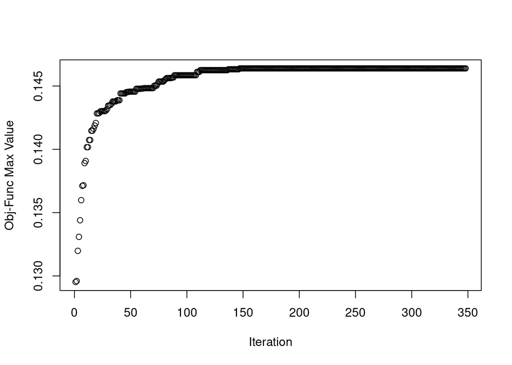

```r
TSOUTCD_75 = do.call('cbind',TSOUTCD_75)
write.csv(TSOUTCD_75, file = "TSOUTCD_75.csv", row.names = F)

#Visualizing convergence
plot(selected$maxvec, xlab = "Iteration", ylab = "Obj-Func Max Value")
```

**Load saved selections**

```r
#cdmean 25
TSOUTCD_25 <- read_csv("TSOUTCD_25.csv"); TSOUTCD_25 = data.frame(TSOUTCD_25)
#cdmean 50
TSOUTCD_50 <- read_csv("TSOUTCD_50.csv"); TSOUTCD_50 = data.frame(TSOUTCD_50)
#cdmean 75
TSOUTCD_75 <- read_csv("TSOUTCD_75.csv"); TSOUTCD_75 = data.frame(TSOUTCD_75)
```

### Comparison of TSO

**Function to run gblup gs: opt and k-fold CVs**

`gs_opt` function runs gblup genomic prediction with the five reps of selected individuals from optimization algorithm. Additionally, `gblup_gs` function runs 10 fold cross-validation for the full dataset. This was used to compare the TSO outputs.

```r
gs_opt = function(G,train_ind,pheno,trait){
  trait_id = which(names(pheno)==trait)
  y = pheno[,trait_id]
  r2_gb = vector()
  reps = ncol(train_ind)
  for (i in 1:reps) {
    sel = train_ind[,i]
    test = which(!pheno[,1] %in% sel)
    yNA = y; yNA[test] = NA
    #Fit - gblub
    fit = mixed.solve(yNA, K=G)
    yhat = fit$u[test]
    r2_gb[i] = cor(yhat, y[test],use="complete")
  }
  return(list(gblup=r2_gb))
}

#10 Folds CV
gblup_gs = function(G,y,reps){
  set.seed(123)
  seed=sample(1:10000,reps,F)
  rep_r2 = list();
  for (i in 1:reps) {
    set.seed(seed[i])
    print(i)
    folds=sample(1:10,size=length(y),replace=T)
    y[is.nan(y)]<-NA

    r2 = vector()
    for (j in 1:max(folds)) {
      test = which(folds==j)
      yNA = y; yNA[test] = NA
      #Fit
      fit = mixed.solve(yNA, K=G)
      yhat = fit$u[test]
      r2[j] = cor(yhat, y[test],use="complete")
    }
    rep_r2[[i]] = r2
  }
  return(rep_r2)
}

cd_25 = gs_opt(G,TSOUTCD_25,pheno_dat,"trait1")
cd_50 = gs_opt(G,TSOUTCD_50,pheno_dat,"trait1")
cd_75 = gs_opt(G,TSOUTCD_75,pheno_dat,"trait1")
all = gblup_gs(G,pheno_dat$trait1,5)
```

### TSO summary

```r
size = c(25, 50, 75, "all")
random = c(mean(rand_25$gblup),mean(rand_50$gblup),
           mean(rand_75$gblup),mean(unlist(all)))
cdmean = c(mean(cd_25$gblup,na.rm=T),mean(cd_50$gblup,na.rm=T),
           mean(cd_75$gblup,na.rm=T),mean(unlist(all)))
tso = data.frame(Size=size,Random=random,CDMean=cdmean)
knitr::kable(tso)
```

| Size | Random | CDMean |
| --- | --- | --- |
| 25 | 0.3233391 | 0.3998368 |
| 50 | 0.3940426 | 0.4173206 |
| 75 | 0.4138347 | 0.5312799 |
| all | 0.4583492 | 0.4583492 |

## Marker Size Optimization (MSO)

**Example 3**

In this example, a defined number of snp markers were randomly sampled to fit genomic prediction models. However, there are other data-driven and genetic methods in literature (MAF, mismatch rate, LD, Call rate etc.) for informed mso (Kainer et al., 2018) (David Kainer 2018). In the example below, 10k snps were randomly selected.

```r
set.seed(123)
#Select random index
size = 10000
sel = sample(1:ncol(geno_dat), size, replace = F)
rand_snp = geno_dat[,sel];
#Select snps
n=length(pheno_dat$trait1); k=10
#set folds
folds=sample(1:k,size=n,replace=T)
#construct g matrix
G_sel = Gmatrix(rand_snp,ploidy = 4)
```

```
## Initial data:
##  Number of Individuals: 138
##  Number of Markers: 10000
##
## Missing data check:
##  Total SNPs: 10000
##   6 SNPs dropped due to missing data threshold of 0.5
##  Total of: 9994  SNPs
##
## MAF check:
##  No SNPs with MAF below 0
##
## Heterozigosity data check:
##  No SNPs with heterozygosity, missing threshold of =  0
##
## Summary check:
##  Initial:  10000 SNPs
##  Final:  9994  SNPs ( 6  SNPs removed)
##
## Completed! Time = 0.685  seconds
```

```r
y = pheno_dat$trait1

#10 cv
r2 = vector()
for(i in 1:max(folds)){
  test = which(folds==i)
  yNA = y
  yNA[test] = NA
  #Fit - gblup
  fit = mixed.solve(yNA, K=G_sel)
  yhat = fit$u[test]
  r2[i] = cor(yhat, y[test],use="complete")
}
mean(r2,na.rm=T)
```

```
## [1] 0.5525211
```

```r
rm(list = c("size","sel","rand_snp","n","folds","G_sel","r2","yNA","fit","yhat","test"))
```

### Comparison of MSO: GBlup vs RRBlup

In the example below, the snp markers were randomly selected with different seeds repeatedly (5 times) to avoid bias using `gblup` and `rrblup` models.

```r
#random marker size selection: gblup
rand_gblup_probes = function(snp,pheno,trait,size){
  reps = list()

  #Set seed to randomly sample 5 numbers
  set.seed(123)
  mod.seed=sample(1:10000,5,F)

  trait_id = which(names(pheno)==trait)
  y = pheno[,trait_id]; y[is.nan(y)]<-NA
  for (j in 1:length(mod.seed)) {
    print(j)
    #Set seed
    set.seed(mod.seed[j])
    #Select random index
    sel = sample(1:ncol(snp), size, replace = F)
    rand_snp = snp[,sel];
    #Select snps
    n=length(y); k=10
    #set folds
    folds=sample(1:k,size=n,replace=T)
    #construct g matrix
    G_sel = Gmatrix(rand_snp,ploidy = 4)

    #10 cv
    r2 = vector()
    for(i in 1:max(folds)){
      test = which(folds==i)
      yNA = y
      yNA[test] = NA
      #Fit - gblup
      fit = mixed.solve(yNA, K=G_sel)
      yhat = fit$u[test]
      r2[i] = cor(yhat, y[test],use="complete")
    }
    reps[[j]]=r2
  }
  print(dim(rand_snp));print(rand_snp[1:5,1:5])
  return(reps)
}

#imputation function
imputation = function(dat){
  if (any(is.na(dat))) {
    imputvalue = apply(dat, 2, mean, na.rm = TRUE)
    ix = which(is.na(dat), arr.ind = TRUE)
    dat[ix] = imputvalue[ix[, 2]]
  }
  return(dat)
}

#random marker size selection: rrblup
rand_rr_probes = function(snp,pheno,trait,size){
  reps = list()

  #Impute missing data
  snp = imputation(snp)

  #Set seed to randomly sample 5 numbers
  set.seed(123)
  mod.seed=sample(1:10000,5,F)

  trait_id = which(names(pheno)==trait)
  y = pheno[,trait_id]; y[is.nan(y)]<-NA
  for (j in 1:length(mod.seed)) {
    print(j)
    #Set seed
    set.seed(mod.seed[j])
    #Select random index
    sel = sample(1:ncol(snp), size, replace = F)
    rand_snp = snp[,sel];
    #Select snps
    n=length(y); k=10
    #set folds
    folds=sample(1:k,size=n,replace=T)

    #10 cv
    r2 = vector()
    for(i in 1:max(folds)){
      test = which(folds==i)
      y_train=y[-test];   y_test = y[test]
      x_train= rand_snp[-test,]; x_test= rand_snp[test,]
      #Fit
      fit = mixed.solve(y_train, x_train)
      yhat = x_test %*% fit$u
      r2[i] = cor(yhat, y_test,use="complete")
    }
    reps[[j]]=r2
  }
  return(reps)
}

rand_gblup_1k = rand_gblup_probes(geno_dat,pheno_dat,"trait1",1000)
rand_gblup_5k = rand_gblup_probes(geno_dat,pheno_dat,"trait1",5000)
rand_gblup_10k = rand_gblup_probes(geno_dat,pheno_dat,"trait1",10000)
rand_gblup_20k = rand_gblup_probes(geno_dat,pheno_dat,"trait1",20000)

rand_rr_1k = rand_rr_probes(geno_dat,pheno_dat,"trait1",1000)
rand_rr_5k = rand_rr_probes(geno_dat,pheno_dat,"trait1",5000)
rand_rr_10k = rand_rr_probes(geno_dat,pheno_dat,"trait1",10000)
rand_rr_20k = rand_rr_probes(geno_dat,pheno_dat,"trait1",20000)
```

### MSO summary

```r
size = c(1000, 5000, 10000, 20000)
gblup = c(mean(unlist(rand_gblup_1k),na.rm=T),mean(unlist(rand_gblup_5k),na.rm=T),
          mean(unlist(rand_gblup_10k),na.rm=T),mean(unlist(rand_gblup_20k),na.rm=T))
rrblup = c(mean(unlist(rand_rr_1k),na.rm=T),mean(unlist(rand_rr_5k),na.rm=T),
           mean(unlist(rand_rr_10k),na.rm=T),mean(unlist(rand_rr_20k),na.rm=T))
mso = data.frame(Size=size,GBlup=gblup,RRBlup=rrblup)

knitr::kable(mso)
```

| Size | GBlup | RRBlup |
| --- | --- | --- |
| 1000 | 0.4335913 | 0.4340556 |
| 5000 | 0.4364223 | 0.4365127 |
| 10000 | 0.4840333 | 0.4840627 |
| 20000 | 0.4541483 | 0.4542154 |

### References

David Kainer, Amanda Padovan, Eric A Stone. 2018. “Accuracy of Genomic Prediction for Foliar Terpene Traits in Eucalyptus Polybractea.” *G3* 8 (8): 2573–83.

Deniz Akdemir, Simon Rio, and Julio Isidro y Sánchez. 2021. “TrainSel: An r Package for Selection of Training Populations.” *Front. Genet.* 12.

Fernández-González, Akdemir, J. 2023. “A Comparison of Methods for Training Population Optimization in Genomic Selection.” *Theor Appl Genet* 136 (30).

Laloë, D. 1993. “Precision and Information in Linear Models of Genetic Evaluation.” *Genet. Select. Evol.* 25: 557–76.

Rincent, Laloë, R. 2012. “Maximizing the Reliability of Genomic Selection by Optimizing the Calibration Set of Reference Individuals: Comparison of Methods in Two Diverse Groups of Maize Inbreds (Zea Mays l.).” *Genetics* 192: 715–28.

[^1]: University of Florida, mresende@ufl.edu
[^2]: University of Florida, https://pauliben.github.io/pauladunola.github.io/index.html